# Covariate Creation

Tejus

01/11/2020

## 2 levels of covariate creation

### 1.) From raw data to covariate

- Depends heavily on application
- The balancing act is summarization vs. information loss
- Examples:
  - Text files: frequency of words, frequency of phrases ([Google ngrams](https://books.google.com/ngrams)), frequency of capital letters.
  - Images: Edges, corners, blobs, ridges (computer vision feature detection)
  - Webpages: Number and type of images, position of elements, colors, videos ([A/B Testing](http://en.wikipedia.org/wiki/A/B_testing))
  - People: Height, weight, hair color, sex, country of origin.
- The more knowledge of the system you have the better the job, you will do.
- When in doubt, err on the side of more features
- Can be automated, but use caution!

### 2.) Transforming tidy covariates

- More necessary for some methods (regression, svms) than for others (classification trees).
- **Note :** Should be done *only on the training set*
- The best approach is through exploratory analysis (plotting/tables)
- New covariates should be added to data frames
- Some common ways are :

#### 1.) Convert factor variables to indicator variables (New Dummy Covariate Creation)

- The function *dummyVars* creates a full set of dummy variables

```r
inTrain <- createDataPartition(y=Wage$wage,
                              p=0.7, list=FALSE)
training <- Wage[inTrain,]; testing <- Wage[-inTrain,]
table(training$jobclass) # our  factor variable to be converted
```

```
##
##  1. Industrial 2. Information
##           1093           1009
```

```r
dummies <- dummyVars(wage ~ jobclass, data = training)
head(predict(dummies, newdata = training))
```

```
##        jobclass.1. Industrial jobclass.2. Information
## 231655                      1                       0
## 86582                       0                       1
## 161300                      1                       0
## 155159                      0                       1
## 11443                       0                       1
## 376662                      0                       1
```

#### 2.) Removing features with zero variation

- If some variables has no variablitiy; resulting in no direct change in the outcome/result, then we can remove that vairable from the prediction.
- *nearZeroVar()_* function diagnoses predictors that have one unique value (i.e. are zero variance predictors) **OR**
- Predictors that have both of the following characteristics: 1. They have very few unique values relative to the number of samples and 2. The ratio of the frequency of the most common value to the frequency of the second most common value is large.

```r
nZero_Predictors <- nearZeroVar(training, saveMetrics = T)
nZero_Predictors
```

```
##            freqRatio percentUnique zeroVar   nzv
## year        1.029155    0.33301618   FALSE FALSE
## age         1.094595    2.85442436   FALSE FALSE
## maritl      3.254464    0.23786870   FALSE FALSE
## race        8.257143    0.19029496   FALSE FALSE
## education   1.478632    0.23786870   FALSE FALSE
## region      0.000000    0.04757374    TRUE  TRUE
## jobclass    1.083251    0.09514748   FALSE FALSE
## health      2.468647    0.09514748   FALSE FALSE
## health_ins  2.299843    0.09514748   FALSE FALSE
## logwage     1.051948   18.79162702   FALSE FALSE
## wage        1.051948   18.79162702   FALSE FALSE
```

#### 3.) Adding spline terms

- Using the `bs()` (Basis Fn) from the `splines` library for generating a matrix for a polynomial spline.
- You pass it a single variable & define what degree polynomial you require using the `df` variable.

```r
library(splines)
bsBasis <- bs(training$age, df = 3) # df = 3, indicates 3 columns (age + age^2 + age^3)
head(bsBasis)
```

```
##              1          2           3
## [1,] 0.0000000 0.00000000 0.000000000
## [2,] 0.2368501 0.02537679 0.000906314
## [3,] 0.4163380 0.32117502 0.082587862
## [4,] 0.4308138 0.29109043 0.065560908
## [5,] 0.3625256 0.38669397 0.137491189
## [6,] 0.3063341 0.42415495 0.195763821
```

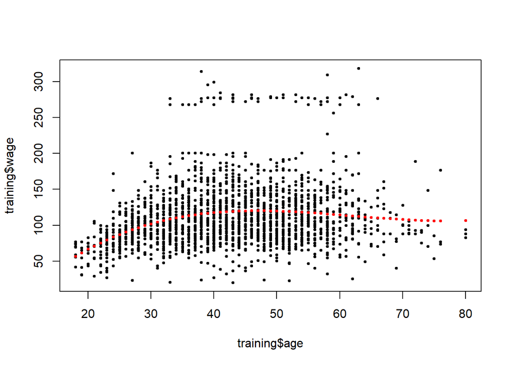

```r
# Plot
lm1 <- lm(wage ~ bsBasis, data = training)
plot(training$age, training$wage, pch = 19, cex = 0.5)
points(training$age, predict(lm1, newdata = training), col = 'red', pch = 19, cex = 0.5)
```

- As you can see in the age v/s wage plot. Curved line better explains the trend
- Splines on the test set. Remember we have to do same modifications (which were done on training data) to test data & hence we use `predict()` with `bsBasis` variable.

```r
New_Age <- predict(bsBasis,age=testing$age)
head(New_Age)
```

```
##              1          2           3
## [1,] 0.0000000 0.00000000 0.000000000
## [2,] 0.2368501 0.02537679 0.000906314
## [3,] 0.4163380 0.32117502 0.082587862
## [4,] 0.4308138 0.29109043 0.065560908
## [5,] 0.3625256 0.38669397 0.137491189
## [6,] 0.3063341 0.42415495 0.195763821
```

#### 4.) Preprocessing with Principal Components Analysis (PCA)

- Multiple quantitative variables, highly correlated with each other can be summarised into lesser number of variables while capturing most variance.
- A weighted combination of predictors might be better
- We should pick the combination to capture the “most information” possible
- Benefits :
  - Reduced number of predictors
  - Reduced noise (due to averaging)

```r
inTrain <- createDataPartition(y = spam$type, p = 0.75, list = FALSE )
training <- spam[inTrain,]; testing <- spam[-inTrain,]

# Looking at the correlation between variables
M <- abs(cor(training[,-58]))
diag(M) <- 0

t(which(M > 0.8, arr.ind = T))
```

```
##     num415 direct num857 direct num857 num415
## row     34     40     32     40     32     34
## col     32     32     34     34     40     40
```

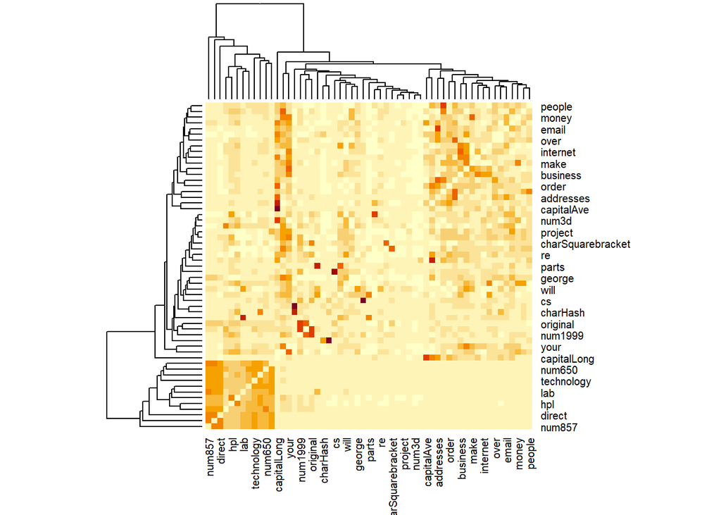

```r
# just for fun; Lower left hand side has cluster of highly correlated vars
heatmap(M)
```

```r
# Names of highly correlated vars
names(spam)[c(32,34,40)]
```

```
## [1] "num857" "num415" "direct"
```

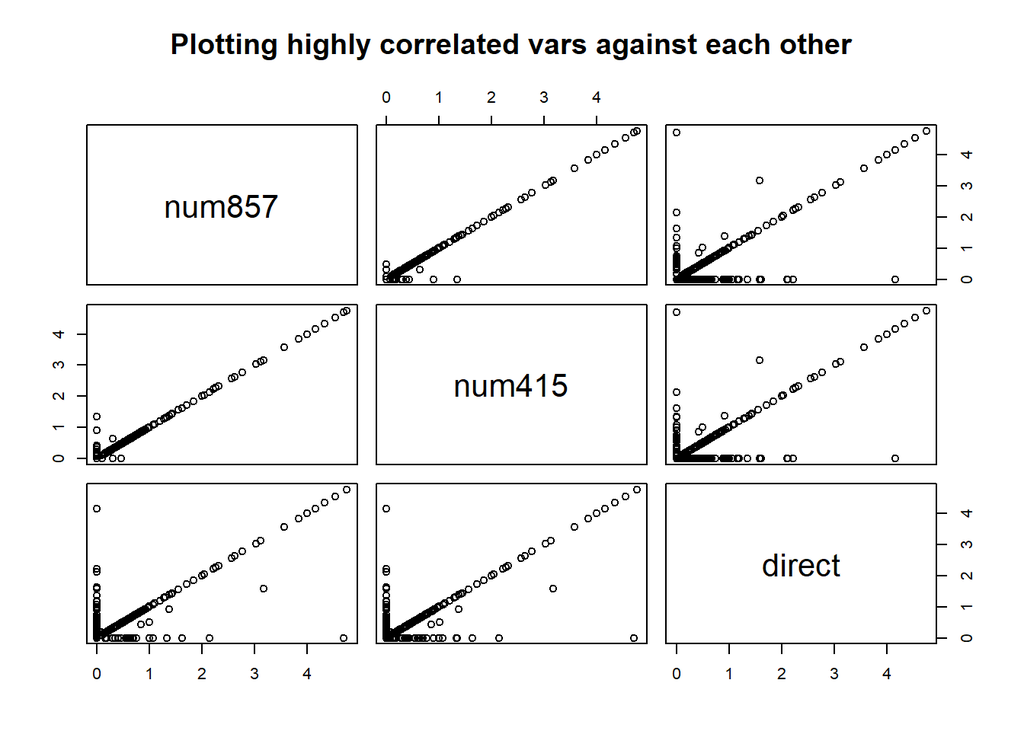

- Thus including all these variables may not be completely necessary.
- 2 related solutions PCA & SVD

**SVD**

If $X$ is a matrix with each variable in a column and each observation in a row then the SVD is a “matrix decomposition”

$$X = UDV^T$$

where the columns of $U$ are orthogonal (left singular vectors), the columns of $V$ are orthogonal (right singluar vectors) and $D$ is a diagonal matrix (singular values).

**PCA**

The principal components are equal to the right singular values if you first scale (subtract the mean, divide by the standard deviation) the variables.

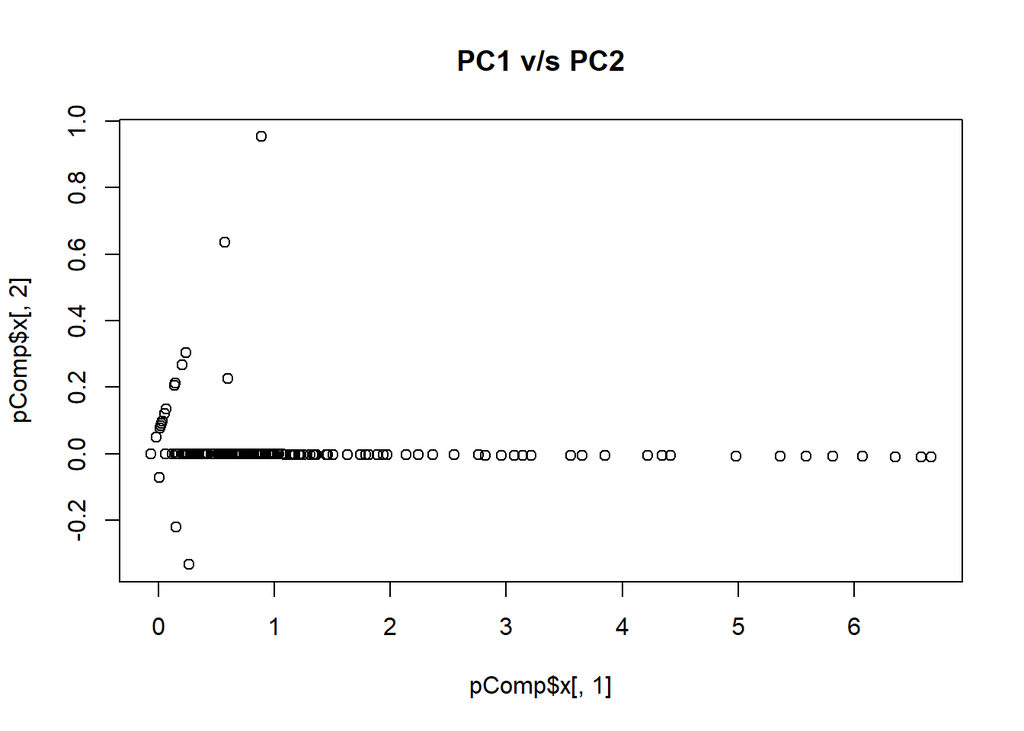

```r
smallSpam <- spam[,c(32,34)]

# Get the principal components (right singular vecors of scaled variables)
pComp <- prcomp(smallSpam)
plot(pComp$x[,1], pComp$x[,2], main = "PC1 v/s PC2")
```

- Rotation matrix tells about the scaling factor for each varaible in each of the Principal components

```r
pComp$rotation
```

```
##              PC1        PC2
## num857 0.7061498 -0.7080625
## num415 0.7080625  0.7061498
```

- **PCA on spam**

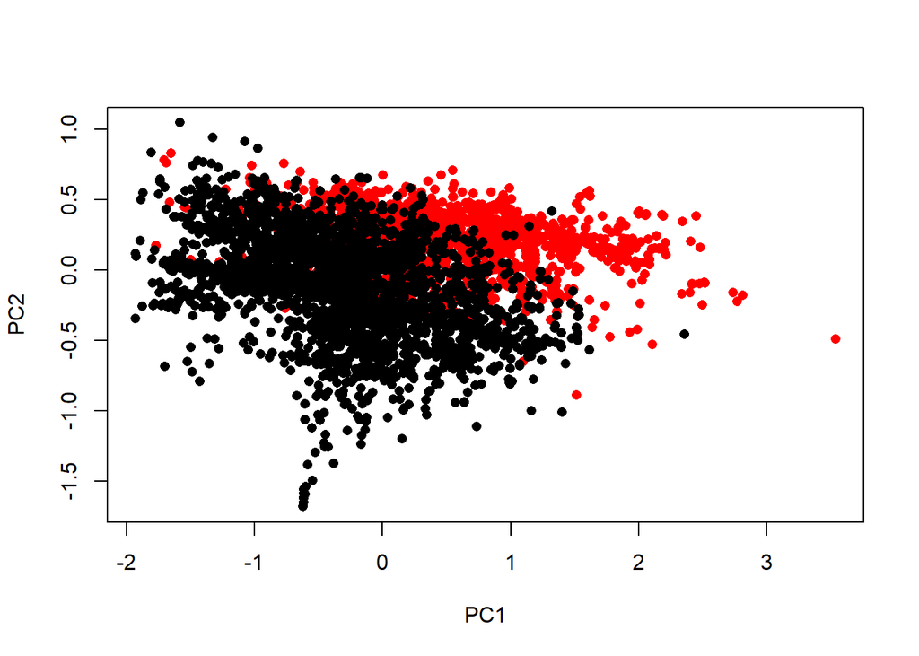

```r
MailCol <- ((spam$type == "spam")*1 + 1)
pComp <- prcomp(log10(spam[,-58]+1))

plot(pComp$x[,1], pComp$x[,2], col=MailCol, xlab="PC1", ylab = "PC2", pch=16)
```

- Now among all the combinations of 57 variables, PC1 represents the combination with highest variance. Also we can see that there is some clear separation explained between red (spam) and black (ham) mails.
- PCA with **caret**

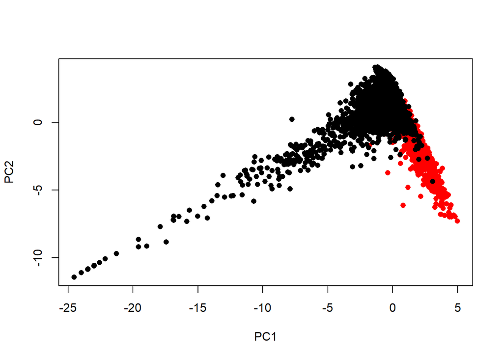

```r
preProc <- preProcess(log10(spam[,-58]+1), method = "pca", pcaComp = 3)
# we have the coefficients for PCs

spamPC <- predict(preProc, newdata= log10(spam[,-58]+1))
plot(spamPC[,1], spamPC[,2], col=MailCol, xlab="PC1", ylab = "PC2", pch=16)
```

- Fitting a model with the new PCA variables

```r
preProc <- preProcess(log10(training[,-58]+1), method ="pca", pcaComp =2)
trainDataPC <- predict(preProc, newdata= log10(training[,-58]+1))
modelFit <- train(y =training$type, method = "glm", x = trainDataPC )

# With testing set
testDataPC <- predict(preProc, newdata = log10(testing[,-58]+1))
confusionMatrix(testing$type, predict(modelFit, testDataPC))
```

```
## Confusion Matrix and Statistics
##
##           Reference
## Prediction nonspam spam
##    nonspam     646   51
##    spam         80  373
##
##                Accuracy : 0.8861
##                  95% CI : (0.8663, 0.9039)
##     No Information Rate : 0.6313
##     P-Value [Acc > NIR] : < 2e-16
##
##                   Kappa : 0.7587
##
##  Mcnemar's Test P-Value : 0.01443
##
##             Sensitivity : 0.8898
##             Specificity : 0.8797
##          Pos Pred Value : 0.9268
##          Neg Pred Value : 0.8234
##              Prevalence : 0.6313
##          Detection Rate : 0.5617
##    Detection Prevalence : 0.6061
##       Balanced Accuracy : 0.8848
##
##        'Positive' Class : nonspam
##
```

- Direct cmd to skip the predict fn step

```r
modelFit <- train(y =training$type, method ="glm", preProcess="pca", x =training[,-58])
confusionMatrix(testing$type, predict(modelFit, testing))
```

```
## Confusion Matrix and Statistics
##
##           Reference
## Prediction nonspam spam
##    nonspam     653   44
##    spam         72  381
##
##                Accuracy : 0.8991
##                  95% CI : (0.8803, 0.9159)
##     No Information Rate : 0.6304
##     P-Value [Acc > NIR] : < 2e-16
##
##                   Kappa : 0.7864
##
##  Mcnemar's Test P-Value : 0.01218
##
##             Sensitivity : 0.9007
##             Specificity : 0.8965
##          Pos Pred Value : 0.9369
##          Neg Pred Value : 0.8411
##              Prevalence : 0.6304
##          Detection Rate : 0.5678
##    Detection Prevalence : 0.6061
##       Balanced Accuracy : 0.8986
##
##        'Positive' Class : nonspam
##
```

#### Final thoughts on PCs

- Most useful for linear-type models
- Can make it harder to interpret predictors
- Watch out for outliers!
  - Transform first (with logs/Box Cox)
  - Plot predictors to identify problems
- For more info see
  - Exploratory Data Analysis course notes
  - [Elements of Statistical Learning](http://statweb.stanford.edu/~tibs/ElemStatLearn/)

## Notes and further reading

- Level 1 feature creation (raw data to covariates)
  - Science is key. Google “feature extraction for [data type]”
  - Err on overcreation of features
  - In some applications (images, voices) automated feature creation is possible/necessary
    - http://www.cs.nyu.edu/~yann/talks/lecun-ranzato-icml2013.pdf
- Level 2 feature creation (covariates to new covariates)
  - The function *preProcess* in *caret* will handle some preprocessing.
  - Create new covariates if you think they will improve fit
  - Use exploratory analysis on the training set for creating them
  - Be careful about overfitting!
- [Preprocessing with caret](http://caret.r-forge.r-project.org/preprocess.html)
- If you want to fit spline models, use the *gam* method in the *caret* package which allows smoothing of multiple variables.
- More on feature creation/data tidying in the Obtaining Data course from the Data Science course track.